# Assignment 5: Mixed models

Marton Kovacs / Zoltan Kekecs

# Introduction

This assignment is related to the previous lab assignment concerning perioperative pain and its psychological and hormonal predictors. Just like previously, you will set up linear model to predict postoperative pain after wisdom tooth surgery, but this time you will have to also take into account the fact that there is clustering in the data.

Your research paper on the effect of the psychological and hormonal predictors of postoperative pain was so successful, that you managed to secure research funding for a multi-site replication study. Here your collaborators collect data in the same way you did in the original study at 20 different hospital sites. The goal of the study is to increase the generalizability of your findings. You would like to assess the model coefficients and the overall predictive efficiency of the predictors in your model.

As a reminder, here is the protocol for data collection: “You have collected data from adults who were scheduled to undergo surgical extraction of the third mandibular molar (wisdom tooth surgery). Patients filled out a form in the waiting room before their surgery. The form contained questions about their sex, age, and weight, and psychological questionnaires assessing anxiety, pain catastrophizing, and mindfulness (see descriptions below). You also got blood samples and saliva samples from participants in the waiting room 5 minutes before their operations to determine the serum (a component of the blood) and salivary cortisol levels of participants. Participants were contacted 5 hours after the surgery to see how much pain they were experiencing. The **level of pain** at that moment was recorded using a numerical rating scale using a **scale of 0 to 10**, where 0 means “no pain” and 10 means “worst pain I can imagine”.

**The State Trait Anxiety Inventory:** T measures trait anxiety on a scale of 20 to 80, higher scores mean higher anxiety. Anxiety has been found in many studies to positively correlate with the level of pain experienced. This is **variable STAI_trait** in the dataset.

**The Pain Catastrophizing Scale** measures the extent of pain catastrophizing, which is characterized by a tendency to magnify the threat value of a pain stimulus and to feel helpless in the presence of pain, as well as by a relative inability to prevent or inhibit pain-related thoughts in anticipation of, during, or following a painful event. The total score on this scale ranges from 0 to 52, higher scores mean higher catastrophizing. Pain catastrophizing is one of the well-established predictors of clinical pain. This is **variable pain_cat** in the dataset.

**The Mindful Attention Awareness Scale (MAAS)** measures dispositional mindfulness, which may be described as a tendency to turn attention to present-moment experiences in an open, non-judgemental way. The MAAS total score ranges from 1 to 6 (an average of the item scores), with higher scores representing higher dispositional mindfulness. Trait mindfulness has been theorized to serve as a protective factor against pain, as the individual would be more objective about their pain experience and tend to associate less discomfort, despair, and hopelessness to the pain-related sensations. This is **variable mindfulness** in the dataset.

**Cortisol** is a stress hormone associated with acute and chronic stress. Cortisol levels are thought to be positively associated with pain experience. Cortisol can be **measured from both blood and the saliva**, although, serum cortisol is often regarded in medical research as more reliably related to stress (serum is a component of the blood plasma). These are **variables cortisol_serum**, and **cortisol_saliva** in the dataset.”

# Datasets

You will need two datasets for this assignment, datafile A and B. You can load them from the ‘data/’ folder.

# Task

First, fit a linear mixed model to estimate postoperative pain on datafile A. You should use the same fixed effect predictors as you used in your final model in the 3 assignment. (If you did not do that assignment, use the following predictors: age, sex, STAI, pain catastrophizing, mindfulness, and serum cortisol.) Importantly, the model has to account for the clustering of the data in different hospital sites. We have no reason to assume that the effects of the different predictors would be different in the different hospitals, so fit a random intercept model including the random intercept of hospital-ID. Once the model is built, note the model coefficients and the confidence intervals of the coefficients for all fixed effect predictors, and compare them to the ones obtained in the 3 assignment.

Also, compute the variance explained by the fixed effect predictors using marginal R<sup>2</sup>, and the variance explained by the fixed and random effect terms combined using conditional R<sup>2</sup>. Now use the model coefficients obtained on data file A to predict pain in datafile B.

**IMPORTANT:** Do not fit the regression models on data file B (don’t re-train your models), just use the regression equation you derived based on datafile A. These regression equations should be applied on the new data (datafile B), to predict pain.

Now compute the variance explained by the model on datafile B. You can do this by using the formula: **1 - (RSS / TSS) = R^2**. Compare this R<sup>2</sup> to the marginal and conditional R<sup>2</sup> values computed for the model on datafile A.

# What to report

Report the model coefficients and the confidence intervals of the coefficients for each fixed effect predictor obtained on data file A in a table.

Report the variance components for the fixed effects, the random intercept, and the residuals (from the model on data file A). Also report the marginal R<sup>2</sup> and the conditional R<sup>2</sup> squared obtained from the model on data file A, and the observed R<sup>2</sup> of this model for data file B.

# What to discuss

Compare the model coefficients and the confidence intervals observed in this assignment and the assignment for Lab 2 and discuss what you think the differences or similarities mean.

# Solution

## Read the data

Read the datasets used in this assignment. Pay attention to the extensions of the datafiles.

```r
df_A <- read_sav("C:/Users/flora/OneDrive/Dokumentumok/GitHub/elte-ppk-r-course-r_data_analysis-23_24_1/data/assignment_4_dataset_A.sav")
df_B <- read_sav("C:/Users/flora/OneDrive/Dokumentumok/GitHub/elte-ppk-r-course-r_data_analysis-23_24_1/data/assignment_4_dataset_B.sav")
```

## Exploratory data analysis

Run an exploratory data analysis (EDA) to investigate the dataset.

```r
head(df_A)
```

```
## # A tibble: 6 × 13
##   ID     pain sex      age STAI_trait pain_cat cortisol_serum cortisol_saliva
##   <chr> <dbl> <chr>  <dbl>      <dbl>    <dbl>          <dbl>           <dbl>
## 1 ID_1      6 male      31         45       34           4.59            5.31
## 2 ID_2      7 female    42         50       31           7.11            7.11
## 3 ID_3      5 male      35         36       30           5.2             5.24
## 4 ID_4      5 female    37         35       26           3.62            3.95
## 5 ID_5      7 female    37         46       38           6.17            6.54
## 6 ID_6      4 female    39         38       28           3.69            3.3
## # ℹ 5 more variables: mindfulness <dbl>, weight <dbl>, IQ <dbl>,
## #   household_income <dbl>, hospital <chr>
```

```r
dim(df_A)
```

```
## [1] 200  13
```

```r
summary(df_A)
```

```
##       ID                 pain            sex                 age
##  Length:200         Min.   : 0.000   Length:200         Min.   :28.00
##  Class :character   1st Qu.: 4.000   Class :character   1st Qu.:37.00
##  Mode  :character   Median : 5.000   Mode  :character   Median :40.00
##                     Mean   : 4.845                      Mean   :39.99
##                     3rd Qu.: 6.000                      3rd Qu.:43.00
##                     Max.   :10.000                      Max.   :51.00
##    STAI_trait       pain_cat     cortisol_serum  cortisol_saliva
##  Min.   :24.00   Min.   :17.00   Min.   :1.640   Min.   :2.090
##  1st Qu.:36.00   1st Qu.:28.00   1st Qu.:4.290   1st Qu.:4.175
##  Median :40.00   Median :30.00   Median :4.970   Median :4.965
##  Mean   :39.66   Mean   :29.98   Mean   :4.914   Mean   :4.901
##  3rd Qu.:43.00   3rd Qu.:33.00   3rd Qu.:5.540   3rd Qu.:5.580
##  Max.   :52.00   Max.   :41.00   Max.   :7.630   Max.   :7.910
##   mindfulness        weight            IQ         household_income
##  Min.   :1.000   Min.   :38.80   Min.   : 59.00   Min.   : -2672
##  1st Qu.:2.265   1st Qu.:62.42   1st Qu.: 90.00   1st Qu.: 51175
##  Median :2.910   Median :69.55   Median :100.00   Median : 66268
##  Mean   :2.998   Mean   :69.57   Mean   : 99.86   Mean   : 68755
##  3rd Qu.:3.830   3rd Qu.:75.58   3rd Qu.:110.00   3rd Qu.: 87047
##  Max.   :5.580   Max.   :93.08   Max.   :148.00   Max.   :151242
##    hospital
##  Length:200
##  Class :character
##  Mode  :character
##
##
##
```

```r
table(df_A$sex)
```

```
##
## female   male   Male
##    103     96      1
```

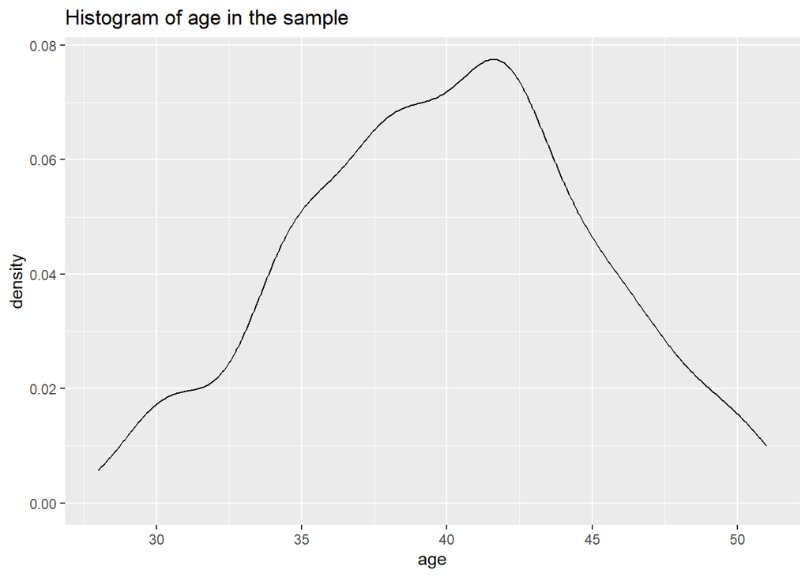

```r
ggplot(df_A, aes(age)) +
  geom_density() +
  labs(title = "Histogram of age in the sample")
```

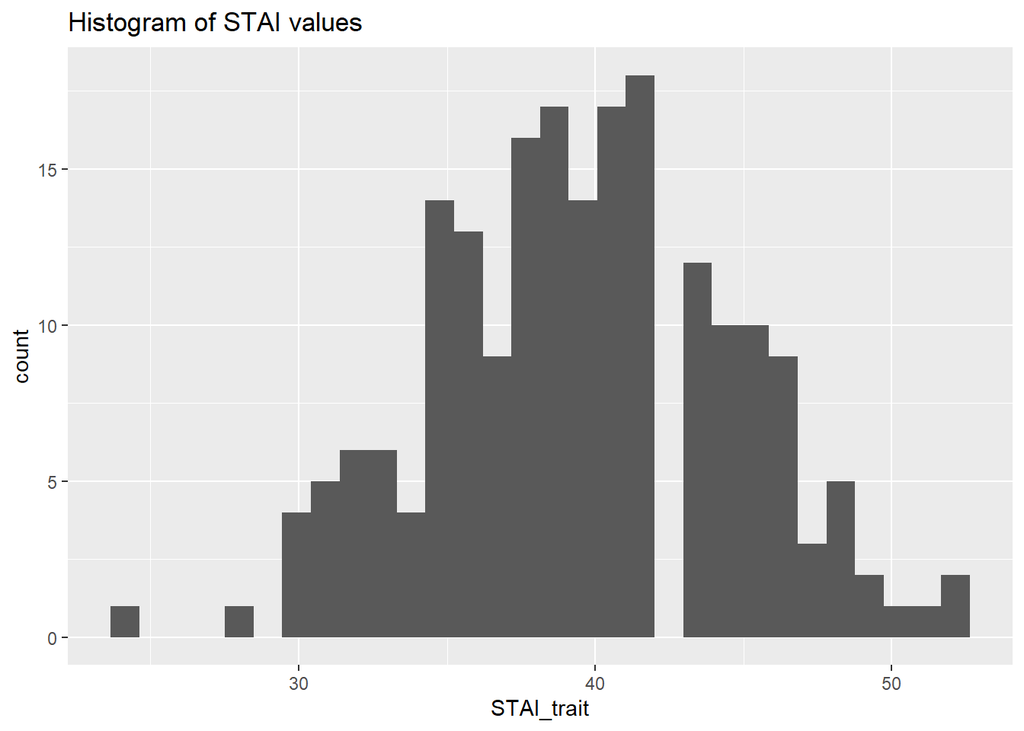

```r
ggplot(df_A, aes(STAI_trait)) +
  geom_histogram() +
  labs(title = "Histogram of STAI values")
```

```r
min(df_A$STAI_trait)
```

```
## [1] 24
```

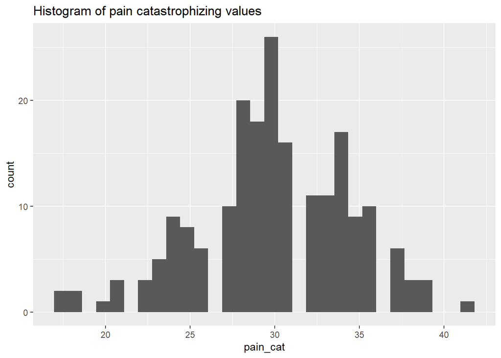

```r
ggplot(df_A, aes(pain_cat)) +
  geom_histogram() +
  labs(title = "Histogram of pain catastrophizing values")
```

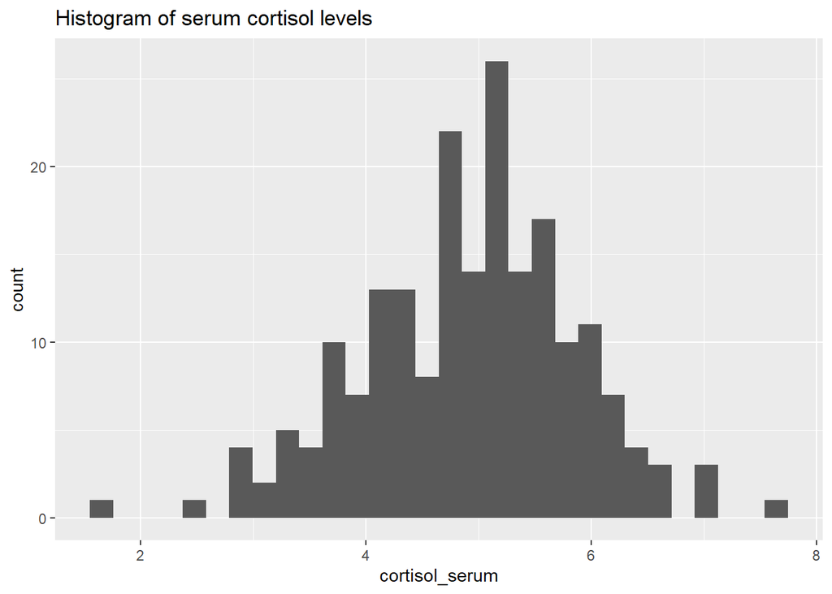

```r
ggplot(df_A, aes(cortisol_serum)) +
  geom_histogram() +
  labs(title = "Histogram of serum cortisol levels")
```

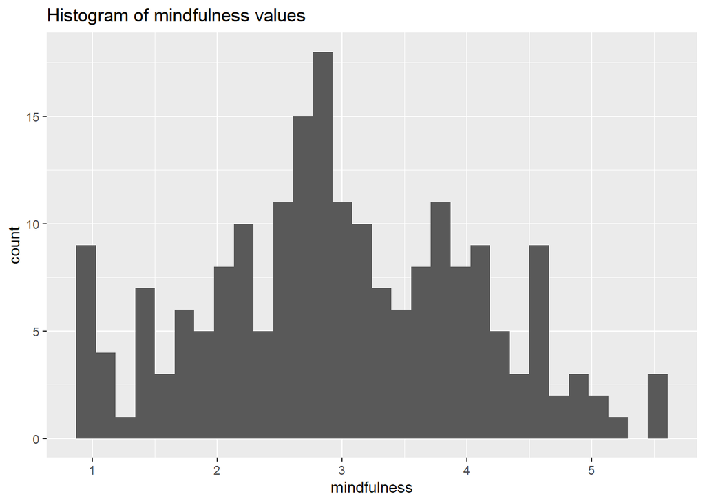

```r
ggplot(df_A, aes(mindfulness)) +
  geom_histogram() +
  labs(title = "Histogram of mindfulness values")
```

[figure not shown]

```r
ggplot(df_A, aes(STAI_trait, group = pain)) +
  geom_boxplot() +
  coord_flip() +
  labs(title = "Boxplot of STAI scores by pain levels")
```

```r
round(cor(df_A[c("pain", "age", "STAI_trait", "pain_cat", "cortisol_serum", "mindfulness")]), 2)
```

```
##                 pain   age STAI_trait pain_cat cortisol_serum mindfulness
## pain            1.00 -0.32       0.27     0.40           0.48       -0.33
## age            -0.32  1.00       0.08    -0.17          -0.23        0.04
## STAI_trait      0.27  0.08       1.00     0.50           0.49       -0.34
## pain_cat        0.40 -0.17       0.50     1.00           0.38       -0.57
## cortisol_serum  0.48 -0.23       0.49     0.38           1.00       -0.22
## mindfulness    -0.33  0.04      -0.34    -0.57          -0.22        1.00
```

```r
sapply(df_A, function(x) sum(is.na(x)))
```

```
##               ID             pain              sex              age
##                0                0                0                0
##       STAI_trait         pain_cat   cortisol_serum  cortisol_saliva
##                0                0                0                0
##      mindfulness           weight               IQ household_income
##                0                0                0                0
##         hospital
##                0
```

```r
table(df_A$hospital)
```

```
##
##  hospital_1 hospital_10  hospital_2  hospital_3  hospital_4  hospital_5
##          20          20          20          20          20          20
##  hospital_6  hospital_7  hospital_8  hospital_9
##          20          20          20          20
```

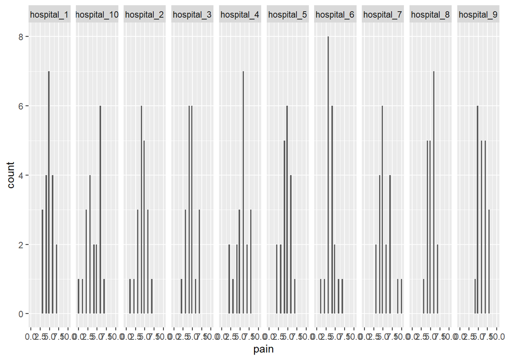

```r
df_A %>%
  ggplot(aes(pain)) +
  geom_histogram() +
  facet_grid(.~hospital)
```

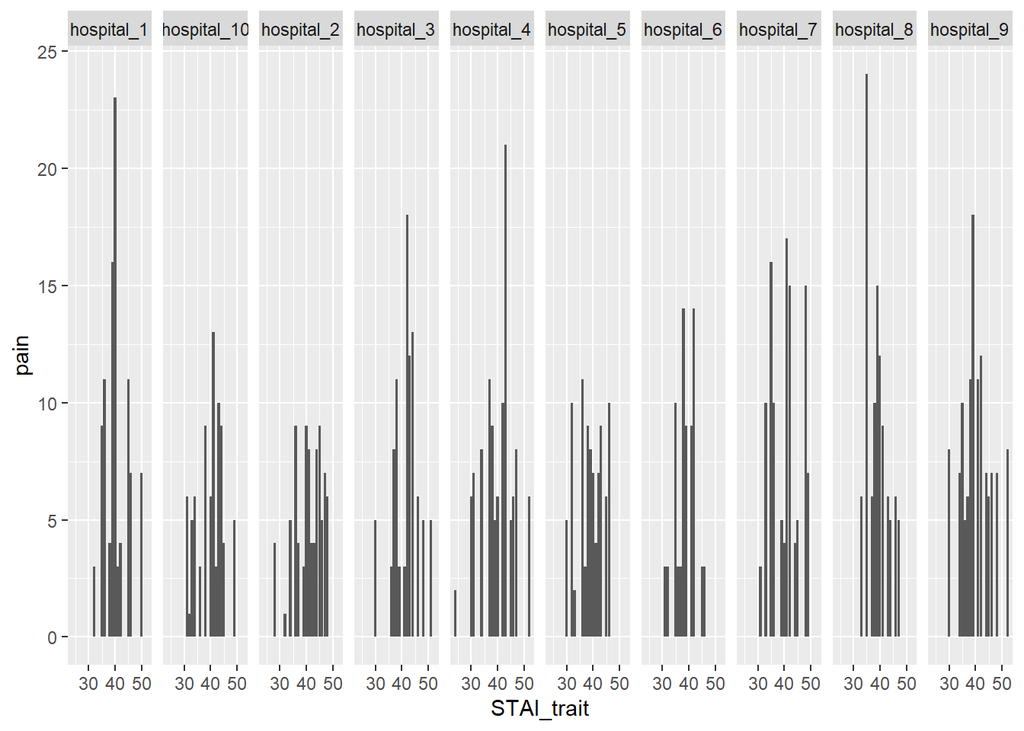

```r
df_A %>%
  ggplot(aes(STAI_trait, pain)) +
  geom_col() +
  facet_grid(.~hospital)
```

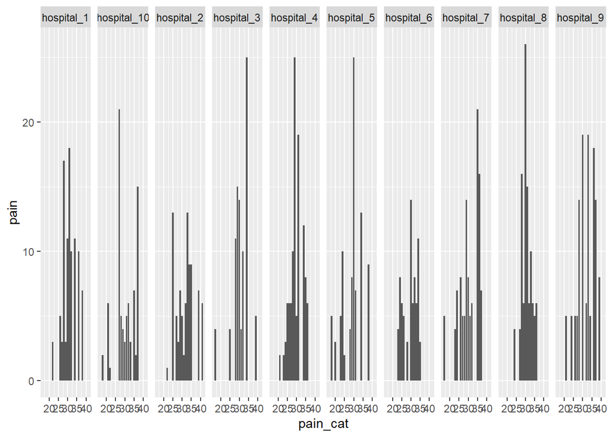

```r
df_A %>%
  ggplot(aes(pain_cat, pain)) +
  geom_col() +
  facet_grid(.~hospital)
```

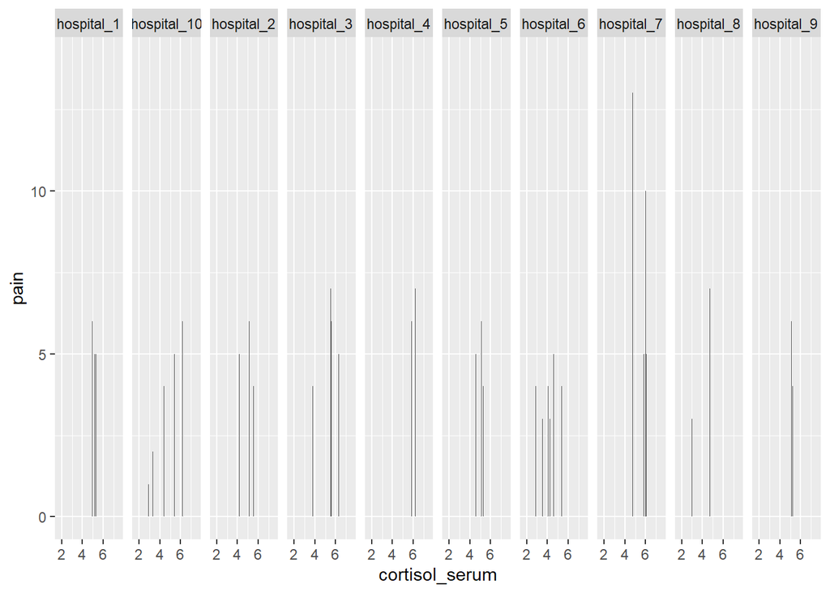

```r
df_A %>%
  ggplot(aes(cortisol_serum, pain)) +
  geom_col() +
  facet_grid(.~hospital)
```

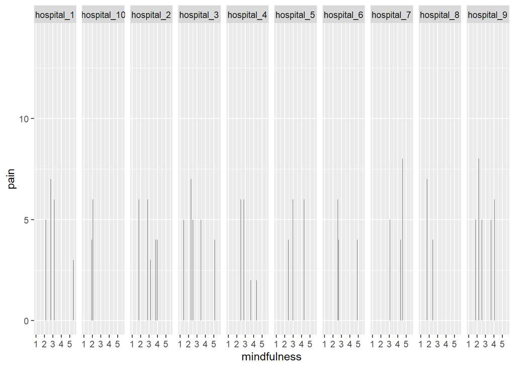

```r
df_A %>%
  ggplot(aes(mindfulness, pain)) +
  geom_col() +
  facet_grid(.~hospital)
```

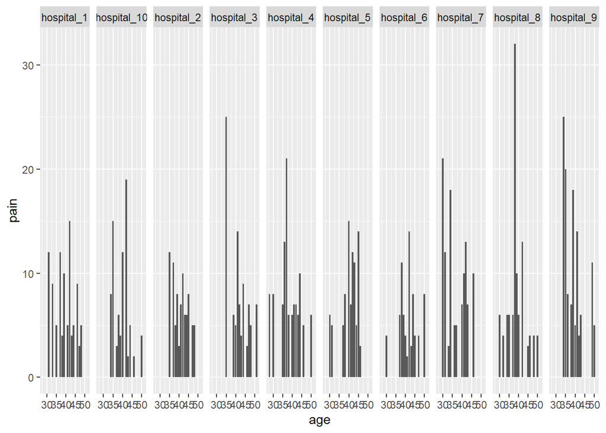

```r
df_A %>%
  ggplot(aes(age, pain)) +
  geom_col() +
  facet_grid(.~hospital)
```

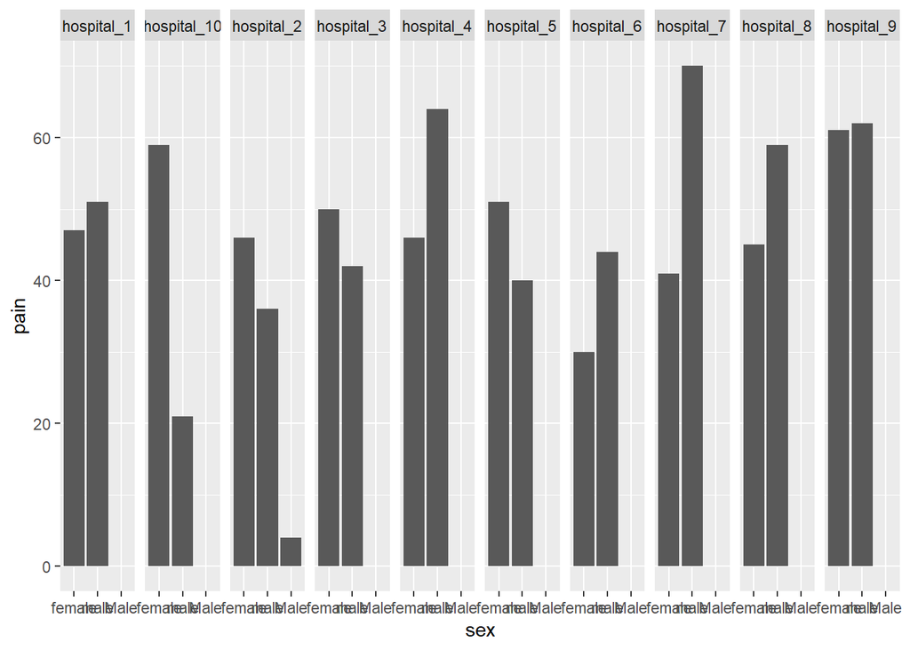

```r
df_A %>%
  ggplot(aes(sex, pain)) +
  geom_col() +
  facet_grid(.~hospital)
```

```r
head(df_B)
```

```
## # A tibble: 6 × 13
##   ID     pain sex      age STAI_trait pain_cat cortisol_serum cortisol_saliva
##   <chr> <dbl> <chr>  <dbl>      <dbl>    <dbl>          <dbl>           <dbl>
## 1 ID_1      9 male      34         46       44           7.47            7.48
## 2 ID_2      4 male      34         32       29           3.53            3.42
## 3 ID_3      5 female    27         36       28           5.61            6.48
## 4 ID_4      6 female    36         32       29           3.36            3.97
## 5 ID_5      4 female    38         37       28           4.09            4.83
## 6 ID_6      3 female    41         37       24           4.26            4.23
## # ℹ 5 more variables: mindfulness <dbl>, weight <dbl>, IQ <dbl>,
## #   household_income <dbl>, hospital <chr>
```

## Correct coding errors

If you find values in the dataset during the EDA, that are not correct based on the provided descriptions of the variables of the dataset please correct them here.

```r
df_A[df_A$sex=='Male', 'sex'] <- 'male'

table(df_A$sex)
```

```
##
## female   male
##    103     97
```

```r
as.factor(df_A$sex)
```

```
##   [1] male   female male   female female female female female male   male
##  [11] male   male   male   male   male   male   female male   female female
##  [21] female male   female male   male   male   female male   female male
##  [31] male   female female female female male   male   male   female female
##  [41] female male   female male   male   female female female male   female
##  [51] female female male   female male   female female male   male   female
##  [61] male   male   male   female female male   male   male   female male
##  [71] male   female female male   female female male   male   female female
##  [81] male   male   female female male   male   female female female female
##  [91] male   male   female female female female female female male   male
## [101] male   male   female male   female male   male   female male   female
## [111] male   female male   female female female female male   male   male
## [121] male   male   female female male   female male   male   male   female
## [131] female male   female male   female male   male   female male   male
## [141] male   male   male   female male   male   female female female male
## [151] male   female female male   female female male   male   female male
## [161] male   male   female female male   male   male   male   female male
## [171] male   female female male   female female male   female female female
## [181] male   male   female female female male   female female female female
## [191] male   female female female female male   female female female female
## Levels: female male
```

## Fit a linear mixed model on dataset A, with fixed effects and random intercept (hospital ID)

```r
model <- lmer(pain ~ sex + age + STAI_trait + pain_cat + cortisol_serum + mindfulness + (1 | hospital), data = df_A)
summary(model)
```

```
## Linear mixed model fit by REML ['lmerMod']
## Formula:
## pain ~ sex + age + STAI_trait + pain_cat + cortisol_serum + mindfulness +
##     (1 | hospital)
##    Data: df_A
##
## REML criterion at convergence: 682.6
##
## Scaled residuals:
##      Min       1Q   Median       3Q      Max
## -3.10080 -0.67358  0.05678  0.66353  2.78802
##
## Random effects:
##  Groups   Name        Variance Std.Dev.
##  hospital (Intercept) 0.3131   0.5596
##  Residual             1.4866   1.2193
## Number of obs: 200, groups:  hospital, 10
##
## Fixed effects:
##                 Estimate Std. Error t value
## (Intercept)     3.502306   1.380454   2.537
## sexmale         0.297545   0.190460   1.562
## age            -0.054400   0.019818  -2.745
## STAI_trait      0.001437   0.023851   0.060
## pain_cat        0.036885   0.028633   1.288
## cortisol_serum  0.610010   0.114260   5.339
## mindfulness    -0.262441   0.100647  -2.608
##
## Correlation of Fixed Effects:
##             (Intr) sexmal age    STAI_t pan_ct crtsl_
## sexmale      0.144
## age         -0.626 -0.206
## STAI_trait  -0.104  0.214 -0.321
## pain_cat    -0.552 -0.358  0.269 -0.400
## cortisl_srm -0.224  0.001  0.261 -0.416 -0.078
## mindfulness -0.569 -0.076  0.056  0.032  0.483  0.003
```

```r
confint(model)
```

```
## Computing profile confidence intervals ...
```

```
##                      2.5 %      97.5 %
## .sig01          0.29275254  0.94853398
## .sigma          1.08880037  1.33177484
## (Intercept)     0.84153742  6.20305781
## sexmale        -0.06956659  0.67142442
## age            -0.09363796 -0.01620546
## STAI_trait     -0.04472838  0.04774798
## pain_cat       -0.01885807  0.09219691
## cortisol_serum  0.38893037  0.83190118
## mindfulness    -0.45779593 -0.06764763
```

```r
model_performance(model)
```

```
## # Indices of model performance
##
## AIC     |    AICc |     BIC | R2 (cond.) | R2 (marg.) |   ICC |  RMSE | Sigma
## -----------------------------------------------------------------------------
## 700.643 | 701.591 | 730.328 |      0.436 |      0.317 | 0.174 | 1.175 | 1.219
```

## Use the previous regression equation on dataset B

```r
df_B$pain = 3.502306 + -0.054400*df_B$age +  0.001437*df_B$STAI_trait + 0.036885*df_B$pain_cat + 0.610010*df_B$cortisol_serum + -0.262441*df_B$mindfulness

model2 <- lmer(pain ~ sex + age + STAI_trait + pain_cat + cortisol_serum + mindfulness + (1 | hospital), data = df_B)
sse <- sum(resid(model2)^2)
ssr <- sum((fitted(model2) - mean(df_B$pain))^2)
sst <- sse + ssr
expl_var <- 1- (ssr / sst)
```

[output not shown]

## Results and discussion

Based on the exploratory data analysis, dataset A was cleaned and corrected for data entry errors and checked for outliers or unusual data.

A linear mixed model was fitted for dataset A, with age, sex, STAI score, pain catastrophizing score, serum cortisol levels and mindfulness score as fixed effects and hospital as a random intercept. The model coefficients and confidence intervals can be seen below.

```r
fixef(model)
```

```
##    (Intercept)        sexmale            age     STAI_trait       pain_cat
##     3.50230567     0.29754490    -0.05439985     0.00143700     0.03688499
## cortisol_serum    mindfulness
##     0.61001003    -0.26244090
```

```r
confint(model)
```

```
## Computing profile confidence intervals ...
```

```
##                      2.5 %      97.5 %
## .sig01          0.29275254  0.94853398
## .sigma          1.08880037  1.33177484
## (Intercept)     0.84153742  6.20305781
## sexmale        -0.06956659  0.67142442
## age            -0.09363796 -0.01620546
## STAI_trait     -0.04472838  0.04774798
## pain_cat       -0.01885807  0.09219691
## cortisol_serum  0.38893037  0.83190118
## mindfulness    -0.45779593 -0.06764763
```

According to the performance diagnostics, the fixed effects of the linear mixed model explained 31.7% (marginal R^2) of the variance of reported pain levels. Fixed effects and random intercept combined (conditional R^2) explained 43.6% of the variance of pain levels. This number is better than the one in Assignment 3 (that one explained only 33.65% of the variance of the outcome variable). The residual variance of the mixed model is 56.4% (1-R^2).

```r
model_performance(model)
```

```
## # Indices of model performance
##
## AIC     |    AICc |     BIC | R2 (cond.) | R2 (marg.) |   ICC |  RMSE | Sigma
## -----------------------------------------------------------------------------
## 700.643 | 701.591 | 730.328 |      0.436 |      0.317 | 0.174 | 1.175 | 1.219
```

```r
residual_variance <- 1 - 0.436

residual_variance
```

```
## [1] 0.564
```